# DAY 1- Residency

## strip plot:

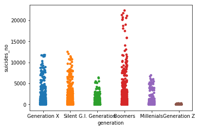

```python
sns.stripplot(x='generation', y='suicides_no', data =df)
sns.mpl.rc('figure', figsize= (30,10))
```

## heatmap()

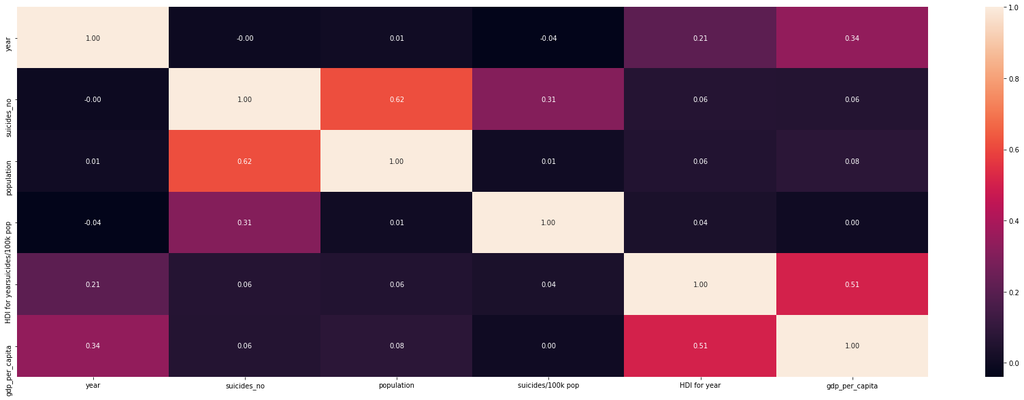

```python
sns.heatmap(df.corr(), annot=True, fmt='.2f')
plt.show()
```

## Box plot

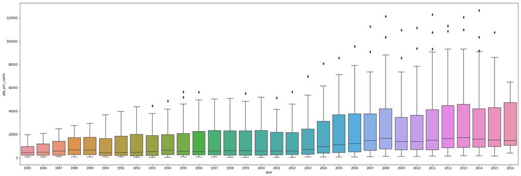

```python
#create box plot for gdp_per_capita:

ax=sns.boxplot(x='year', y='gdp_per_capita', data=df)
sns.mpl.rc('figure', figsize=(30,10))
```

```python
#remove outliers by interquartile range:
Q1= df['gdp_per_capita'].quantile(0.25)
Q3= df['gdp_per_capita'].quantile(0.75)
IQR=Q3- Q1

df_o= df[(df['gdp_per_capita']>Q1 -1.5*IQR) & (df['gdp_per_capita']<Q3 +1.5*IQR)]
```

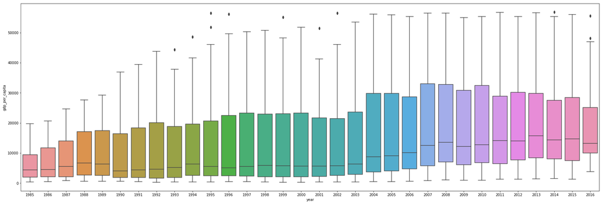

```python
sns.boxplot(x='year', y='gdp_per_capita', data=df_o)
sns.mpl.rc('figure', figsize=(30,10))
```

# Matplotlib basics:

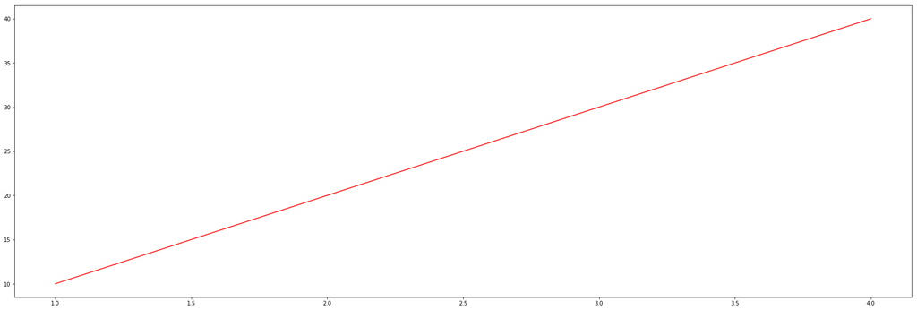

```python
x=[1,2,3,4]
y=[10,20,30,40]
plt.plot(x,y, 'r-') #'r-' is red and plot is dash viz a line. 'b.' blue dotted will be printed
```

```python
data=np.arange(0,6,0.2)
data
```

```
array([0. , 0.2, 0.4, 0.6, 0.8, 1. , 1.2, 1.4, 1.6, 1.8, 2. , 2.2, 2.4,
       2.6, 2.8, 3. , 3.2, 3.4, 3.6, 3.8, 4. , 4.2, 4.4, 4.6, 4.8, 5. ,
       5.2, 5.4, 5.6, 5.8])
```

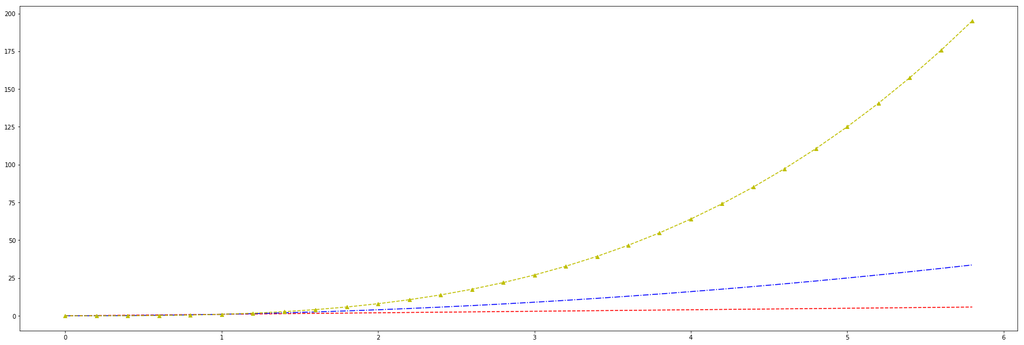

```python
plt.plot(data, data, 'r--', data, data**2, 'b-.', data, data**3, 'y^--')
plt.show()
```

## House train:

```python
df=pd.read_csv('house_train.csv')
```

```python
pd.options.display.max_columns=None
df.head()
```

|  | Id | MSSubClass | MSZoning | LotFrontage | LotArea | Street | Alley | LotShape | LandContour | Utilities | LotConfig | LandSlope | Neighborhood | Condition1 | Condition2 | BldgType | HouseStyle | OverallQual | OverallCond | YearBuilt | YearRemodAdd | RoofStyle | RoofMatl | Exterior1st | Exterior2nd | MasVnrType | MasVnrArea | ExterQual | ExterCond | … |
| --- | --- | --- | --- | --- | --- | --- | --- | --- | --- | --- | --- | --- | --- | --- | --- | --- | --- | --- | --- | --- | --- | --- | --- | --- | --- | --- | --- | --- | --- | --- |
| 0 | 1 | 60 | RL | 65.0 | 8450 | Pave | NaN | Reg | Lvl | AllPub | Inside | Gtl | CollgCr | Norm | Norm | 1Fam | 2Story | 7 | 5 | 2003 | 2003 | Gable | CompShg | VinylSd | VinylSd | BrkFace | 196.0 | Gd | TA | … |
| 1 | 2 | 20 | RL | 80.0 | 9600 | Pave | NaN | Reg | Lvl | AllPub | FR2 | Gtl | Veenker | Feedr | Norm | 1Fam | 1Story | 6 | 8 | 1976 | 1976 | Gable | CompShg | MetalSd | MetalSd | None | 0.0 | TA | TA | … |
| 2 | 3 | 60 | RL | 68.0 | 11250 | Pave | NaN | IR1 | Lvl | AllPub | Inside | Gtl | CollgCr | Norm | Norm | 1Fam | 2Story | 7 | 5 | 2001 | 2002 | Gable | CompShg | VinylSd | VinylSd | BrkFace | 162.0 | Gd | TA | … |
| 3 | 4 | 70 | RL | 60.0 | 9550 | Pave | NaN | IR1 | Lvl | AllPub | Corner | Gtl | Crawfor | Norm | Norm | 1Fam | 2Story | 7 | 5 | 1915 | 1970 | Gable | CompShg | Wd Sdng | Wd Shng | None | 0.0 | TA | TA | … |
| 4 | 5 | 60 | RL | 84.0 | 14260 | Pave | NaN | IR1 | Lvl | AllPub | FR2 | Gtl | NoRidge | Norm | Norm | 1Fam | 2Story | 8 | 5 | 2000 | 2000 | Gable | CompShg | VinylSd | VinylSd | BrkFace | 350.0 | Gd | TA | … |

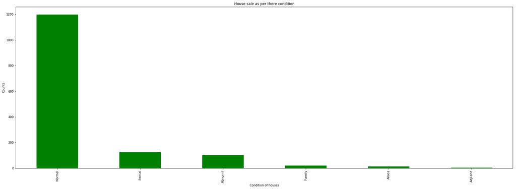

```python
df.SaleCondition.value_counts().plot(kind='bar', color='g')
plt.title('House sale as per there condition')
plt.ylabel('Counts')
plt.xlabel('Condition of houses')
```

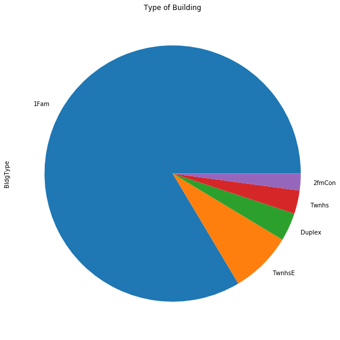

```python
df.BldgType.value_counts().plot(kind='pie')
plt.title('Type of Building')
```

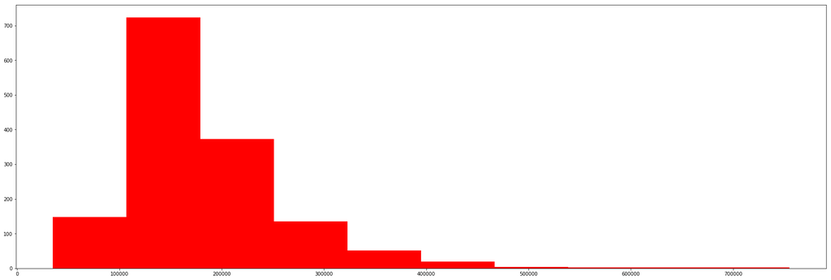

```python
plt.hist(df.SalePrice, bins=10, color='r')
plt.show()
```

[output not shown]

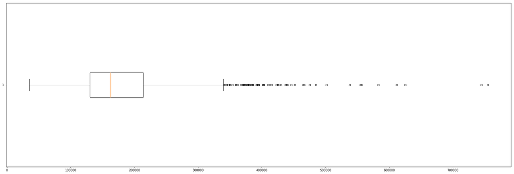

```python
plt.boxplot(df.SalePrice, vert=0)
```

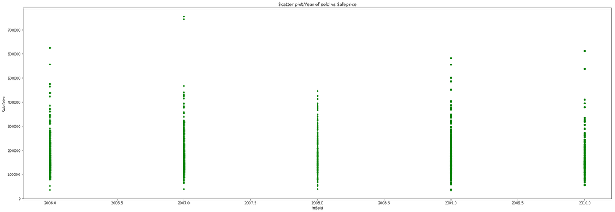

```python
df.plot.scatter(x='YrSold', y='SalePrice', color='g', title ='Scatter plot:Year of sold vs Saleprice' )
```

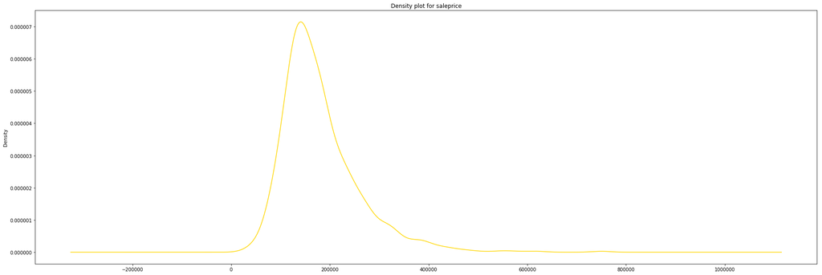

```python
df.SalePrice.plot(kind='kde', title='Density plot for saleprice', color='gold')
```

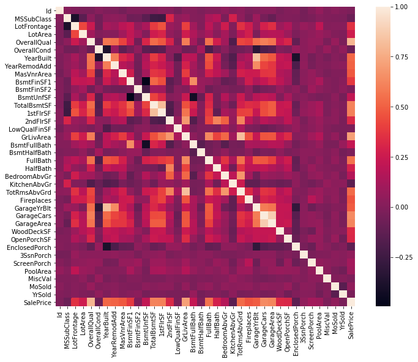

```python
correlatedmat=df.corr()
f,ax=plt.subplots(figsize= (12,9))
sns.heatmap(correlatedmat, square=1)
```

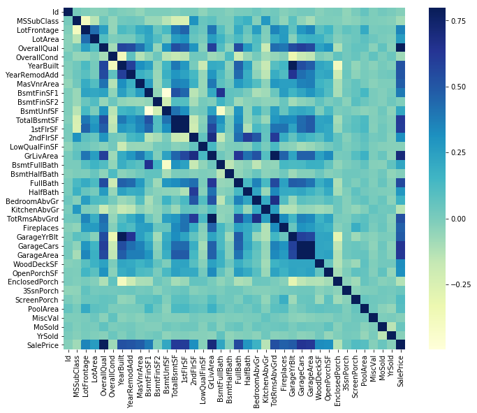

```python
correlatedmat=df.corr()
f,ax=plt.subplots(figsize= (12,9))
sns.heatmap(correlatedmat, vmax=.8 ,square=True,cmap='YlGnBu')
```

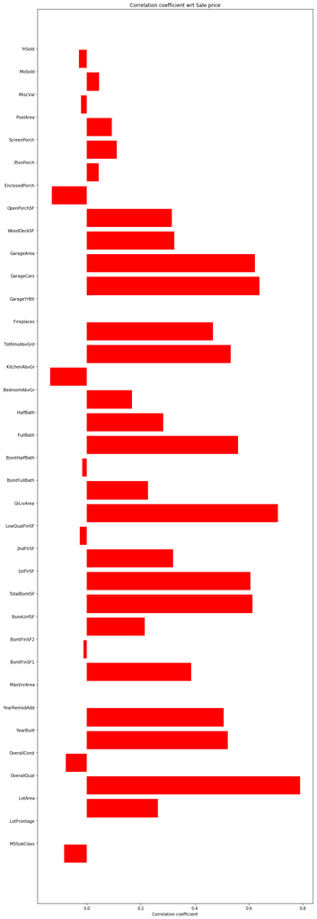

```python
num_feat=df.columns[df.dtypes!=object]
num_feat=num_feat[1:-1]
labels=[]
values=[]
for col in num_feat:
    labels.append(col)
    values.append(np.corrcoef(df[col].values, df.SalePrice.values)[0,1])
ind= np.arange(len(labels))
width=0.9
fix,ax= plt.subplots(figsize=(12,40))
rects= ax.barh(ind, np.array(values), color='r')
ax.set_yticks(ind+((width)/2.))
ax.set_yticklabels(labels, rotation='horizontal')
ax.set_xlabel('Correlation coefficient')
ax.set_title('Correlation coefficient wrt Sale price')
```

## In class & take home day4

**Q.no(16). Write a code to show the `distplot` on `price` column for `automobile dataset` `including 'rug'` and shade.[using seaborn]**

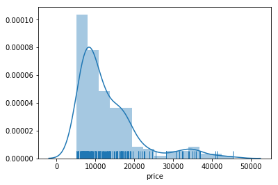

```python
sns.distplot(df.price, rug=1)
```

**Q.no(17). Write a code to show the `regressionplot` on `x-axis='city_mpg'`,`y-axis='highway_mpg'` for `automobile dataset` `including 'marker'` and color was `red`.[using seaborn]**

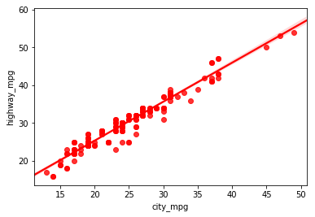

```python
x=df.city_mpg
y=df.highway_mpg
sns.regplot(x, y , marker='o', color='r')
```

**Q.no(18). Write a code to show the `lmplot` on `x-axis='city_mpg'`,`y-axis='highway_mpg'` for `automobile dataset` `including 'marker'` and color was `red`.[using seaborn]**

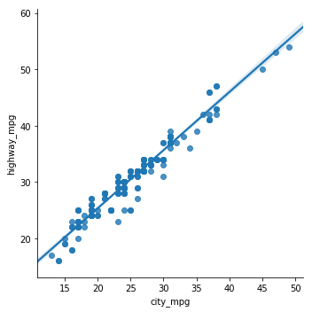

```python
sns.lmplot(x='city_mpg',y='highway_mpg', data=df, palette='Rd' )
```

**Q.no(19). Write a code to show the `lmplot` on `x-axis='price'`,`y-axis='horsepower'` for `automobile dataset` including `col='engine_type'`.[using seaborn]**

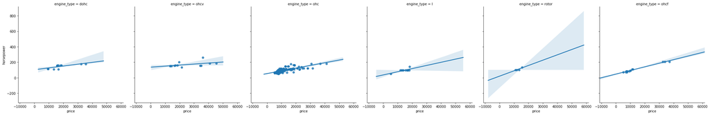

```python
sns.lmplot(x='price', y='horsepower', data=df, col='engine_type')
```

**Q.no(21). Write a code to show `swarmplot` on `x-axis-'engine_type'` and `y-axis-'price'` for `automobile` dataset.**

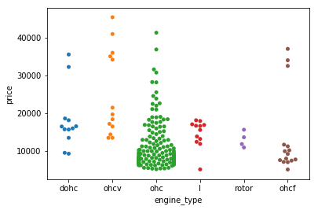

```python
sns.swarmplot(x='engine_type', y='price', data=df)
```

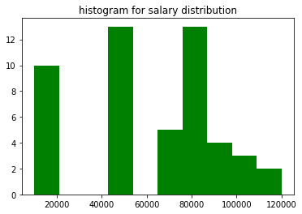

```python
df1=df.Salary
df1=df.Salary
plt.title('histogram for salary distribution')
plt.hist(df1, bins=10, color='g')
plt.show()
```

# Refresher by Sethil

```python
data=pd.read_csv('HR_data.csv')
```

```python
data.head(2)
```

|  | Age | Workclass | fnlwgt | Education | Education_Num | Martial_Status | Occupation | Relationship | Race | Gender | Capital_Gain | Capital_Loss | Hours_per_week | Country | Target |
| --- | --- | --- | --- | --- | --- | --- | --- | --- | --- | --- | --- | --- | --- | --- | --- |
| 0 | 39 | State-gov | 77516 | Bachelors | 13 | Never-married | Adm-clerical | Not-in-family | White | Male | 2174 | 0 | 40 | United-States | <=50K |
| 1 | 50 | Self-emp-not-inc | 83311 | Bachelors | 13 | Married-civ-spouse | Exec-managerial | Husband | White | Male | 0 | 0 | 13 | United-States | <=50K |

```python
#data.ix[0]
```

```python
data[data['Country']=='United-States']
```

|  | Age | Workclass | fnlwgt | Education | Education_Num | Martial_Status | Occupation | Relationship | Race | Gender | Capital_Gain | Capital_Loss | Hours_per_week | Country | Target |
| --- | --- | --- | --- | --- | --- | --- | --- | --- | --- | --- | --- | --- | --- | --- | --- |

```python
data['Country']=data['Country'].str.strip().str.lower()
data['Country'].head()
```

[output not shown]

```python
data['Country']=data['Country'].replace('united-states','unitedstates')
```

```python
data['Age_group3'] = data['Age'].apply(lambda x: 'old' if x >40 else 'young')
```

```python
data['Age_group4'] = data['Age'].apply(lambda x: 'young' if x <30 else 'Mid' if x>30 and x <50 else 'old')
```

```python
data[['Age','Age_group4']]
```

|  | Age | Age_group4 |
| --- | --- | --- |
| 0 | 39 | Mid |
| 1 | 50 | old |
| 2 | 38 | Mid |
| 3 | 53 | old |
| 4 | 28 | young |
| ... | ... | ... |
| 36522 | 39 | Mid |
| 36523 | 64 | old |
| 36524 | 38 | Mid |
| 36525 | 44 | Mid |
| 36526 | 35 | Mid |

36527 rows × 2 columns

```python
data['d'] = data.apply(lambda x: x['Age'] + x['Hours_per_week'],axis=1)
```

```python
data['d']
```

```
0         79
1         63
2         78
3         93
4         68
        ...
36522     75
36523    104
36524     88
36525     84
36526     95
Name: d, Length: 36527, dtype: int64
```

```python
data.groupby('Age_group')['Hours_per_week'].mean()
```

```
Age_group
Mid      42.072453
old      42.316923
young    36.520534
Name: Hours_per_week, dtype: float64
```

```python
data['Age_avg_horu']=data.groupby('Age_group')['Hours_per_week'].transform('mean')
```

```python
loan=pd.read_csv('Loan_data.csv')
```

```python
loan['LoanAmount'].fillna(loan.groupby('Gender')['LoanAmount'].transform('mean'))
```

```
0      149.265957
1      128.000000
2       66.000000
3      120.000000
4      141.000000
          ...
609     71.000000
610     40.000000
611    253.000000
612    187.000000
613    133.000000
Name: LoanAmount, Length: 614, dtype: float64
```

```python
data['Target'].unique()
```

```
array([' <=50K', ' >50K', ' <=50K.', ' >50K.'], dtype=object)
```

```python
data['Target1']=data['Target'].replace({' <=50K':0,' <=50K.':0,' >50K':1,' >50K.':1})
```

```python
data['Target1'].unique()
```

```
array([0, 1], dtype=int64)
```

```python
data['Target1'].value_counts()
```

```
0    27721
1     8806
Name: Target1, dtype: int64
```

```python
data['Target'].value_counts()
```

```
 <=50K     24720
 >50K       7841
 <=50K.     3001
 >50K.       965
Name: Target, dtype: int64
```

```python
data.groupby('Race').agg({'Age':['mean'],'Hours_per_week':['min','max']})
```

| Race | Age mean | Hours_per_week min | Hours_per_week max |
| --- | --- | --- | --- |
| Amer-Indian-Eskimo | 37.094828 | 3 | 84 |
| Asian-Pac-Islander | 37.751077 | 1 | 99 |
| Black | 37.806838 | 1 | 99 |
| Other | 33.448718 | 5 | 98 |
| White | 38.792890 | 1 | 99 |

```python
data.groupby(['Race','Gender'])['Age'].mean()
```

```
Race                 Gender
 Amer-Indian-Eskimo   Female    37.050725
                      Male      37.123810
 Asian-Pac-Islander   Female    35.219697
                      Male      39.061438
 Black                Female    37.816551
                      Male      37.797419
 Other                Female    31.580645
                      Male      34.680851
 White                Female    36.809920
                      Male      39.692795
Name: Age, dtype: float64
```

```python
data.groupby(['Race','Gender'])['Age'].mean().reset_index()
```

|  | Race | Gender | Age |
| --- | --- | --- | --- |
| 0 | Amer-Indian-Eskimo | Female | 37.050725 |
| 1 | Amer-Indian-Eskimo | Male | 37.123810 |
| 2 | Asian-Pac-Islander | Female | 35.219697 |
| 3 | Asian-Pac-Islander | Male | 39.061438 |
| 4 | Black | Female | 37.816551 |
| 5 | Black | Male | 37.797419 |
| 6 | Other | Female | 31.580645 |
| 7 | Other | Male | 34.680851 |
| 8 | White | Female | 36.809920 |
| 9 | White | Male | 39.692795 |

```python
data.groupby(['Gender','Race'])['Age'].mean().unstack()
```

| Race Gender | Amer-Indian-Eskimo | Asian-Pac-Islander | Black | Other | White |
| --- | --- | --- | --- | --- | --- |
| Female | 37.050725 | 35.219697 | 37.816551 | 31.580645 | 36.809920 |
| Male | 37.123810 | 39.061438 | 37.797419 | 34.680851 | 39.692795 |

```python
import numpy as np
pd.pivot_table(data,index='Gender',columns='Race',values='Age',aggfunc=np.mean)
```

| Race Gender | Amer-Indian-Eskimo | Asian-Pac-Islander | Black | Other | White |
| --- | --- | --- | --- | --- | --- |
| Female | 37.050725 | 35.219697 | 37.816551 | 31.580645 | 36.809920 |
| Male | 37.123810 | 39.061438 | 37.797419 | 34.680851 | 39.692795 |

```python
pd.pivot_table(data,index='Gender',columns='Race',values='Age',aggfunc=np.mean)
```

[output not shown]

```python
pd.crosstab(index=data['Gender'],columns=data['Race'],values=data['Age'],aggfunc=np.mean)
```

| Race Gender | Amer-Indian-Eskimo | Asian-Pac-Islander | Black | Other | White |
| --- | --- | --- | --- | --- | --- |
| Female | 37.050725 | 35.219697 | 37.816551 | 31.580645 | 36.809920 |
| Male | 37.123810 | 39.061438 | 37.797419 | 34.680851 | 39.692795 |

```python
data2=pd.read_csv('mapping.csv')
```

```python
data2 = data2.set_index('category_list')
data2.head(2)
```

| category_list | Automotive & Sports | Blanks | Cleantech / Semiconductors | Entertainment | Health | Manufacturing | News, Search and Messaging | Others | Social, Finance, Analytics, Advertising |
| --- | --- | --- | --- | --- | --- | --- | --- | --- | --- |
| NaN | 0 | 1 | 0 | 0 | 0 | 0 | 0 | 0 | 0 |
| 3D | 0 | 0 | 0 | 0 | 0 | 1 | 0 | 0 | 0 |

```python
for i in data2.columns:
    data2[data2[i]==1] = i
data3=data2.iloc[:,0].reset_index()
data3
```

|  | category_list | Automotive & Sports |
| --- | --- | --- |
| 0 | NaN | Blanks |
| 1 | 3D | Manufacturing |
| 2 | 3D Printing | Manufacturing |
| 3 | 3D Technology | Manufacturing |
| 4 | Accounting | Social, Finance, Analytics, Advertising |
| ... | ... | ... |
| 683 | Wholesale | Others |
| 684 | Wine And Spirits | Entertainment |
| 685 | Wireless | Entertainment |
| 686 | Women | Others |
| 687 | Young Adults | Others |

688 rows × 2 columns

```python
df1 =pd.read_csv('https://raw.githubusercontent.com/tkseneee/Dataset/master/HR_data.csv')
df1.head()
```

|  | Age | Workclass | fnlwgt | Education | Education_Num | Martial_Status | Occupation | Relationship | Race | Gender | Capital_Gain | Capital_Loss | Hours_per_week | Country | Target |
| --- | --- | --- | --- | --- | --- | --- | --- | --- | --- | --- | --- | --- | --- | --- | --- |
| 0 | 39 | State-gov | 77516 | Bachelors | 13 | Never-married | Adm-clerical | Not-in-family | White | Male | 2174 | 0 | 40 | United-States | <=50K |
| 1 | 50 | Self-emp-not-inc | 83311 | Bachelors | 13 | Married-civ-spouse | Exec-managerial | Husband | White | Male | 0 | 0 | 13 | United-States | <=50K |
| 2 | 38 | Private | 215646 | HS-grad | 9 | Divorced | Handlers-cleaners | Not-in-family | White | Male | 0 | 0 | 40 | United-States | <=50K |
| 3 | 53 | Private | 234721 | 11th | 7 | Married-civ-spouse | Handlers-cleaners | Husband | Black | Male | 0 | 0 | 40 | United-States | <=50K |
| 4 | 28 | Private | 338409 | Bachelors | 13 | Married-civ-spouse | Prof-specialty | Wife | Black | Female | 0 | 0 | 40 | Cuba | <=50K |

```python
df1.loc[0,'Age']
```

```
39
```

```python
df1['Country'].value_counts()
```

```
 United-States                 32722
 Mexico                          712
 Philippines                     222
 Germany                         155
 Canada                          140
 Puerto-Rico                     132
 El-Salvador                     114
 India                           112
 Cuba                            105
 England                          97
 China                            93
 South                            92
 Jamaica                          86
 Italy                            82
 Dominican-Republic               79
 Vietnam                          75
 Japan                            71
 Guatemala                        69
 Columbia                         68
 Poland                           62
 Taiwan                           55
 Iran                             51
 Haiti                            48
 Portugal                         44
 Nicaragua                        38
 Greece                           36
 Peru                             33
 Ecuador                          31
 France                           31
 Ireland                          27
 Hong                             24
 Trinadad&Tobago                  23
 Cambodia                         22
 Thailand                         20
 Laos                             20
 Yugoslavia                       17
 Outlying-US(Guam-USVI-etc)       17
 Scotland                         16
 Hungary                          15
 Honduras                         14
 Holand-Netherlands                1
Name: Country, dtype: int64
```

```python
df1[df1['Country']==' United-States'].count()
```

```
Age               32722
Workclass         30839
fnlwgt            32722
Education         32722
Education_Num     32722
Martial_Status    32722
Occupation        30831
Relationship      32722
Race              32722
Gender            32722
Capital_Gain      32722
Capital_Loss      32722
Hours_per_week    32722
Country           32722
Target            32722
dtype: int64
```

```python
df1['Country'].str.strip(' ').unique()
```

```
array(['United-States', 'Cuba', 'Jamaica', 'India', nan, 'Mexico',
       'South', 'Puerto-Rico', 'Honduras', 'England', 'Canada', 'Germany',
       'Iran', 'Philippines', 'Italy', 'Poland', 'Columbia', 'Cambodia',
       'Thailand', 'Ecuador', 'Laos', 'Taiwan', 'Haiti', 'Portugal',
       'Dominican-Republic', 'El-Salvador', 'France', 'Guatemala',
       'China', 'Japan', 'Yugoslavia', 'Peru',
       'Outlying-US(Guam-USVI-etc)', 'Scotland', 'Trinadad&Tobago',
       'Greece', 'Nicaragua', 'Vietnam', 'Hong', 'Ireland', 'Hungary',
       'Holand-Netherlands'], dtype=object)
```

```python
df1['Age'].max()
```

```
90
```

```python
pd.cut(df1['Age'], bins=[0,40,100], labels=['young', 'old']).head(15)
```

```
0     young
1       old
2     young
3       old
4     young
5     young
6       old
7       old
8     young
9       old
10    young
11    young
12    young
13    young
14    young
Name: Age, dtype: category
Categories (2, object): [young < old]
```

```python
df1['Age'].apply(lambda x: 'old' if x>40 else 'young').head(15)
```

```
0     young
1       old
2     young
3       old
4     young
5     young
6       old
7       old
8     young
9       old
10    young
11    young
12    young
13    young
14    young
Name: Age, dtype: object
```

```python
pd.cut(df1['Age'], bins=[0,30,50,100], labels=['young', 'Mid', 'old']).head(15)
```

```
0       Mid
1       Mid
2       Mid
3       old
4     young
5       Mid
6       Mid
7       old
8       Mid
9       Mid
10      Mid
11    young
12    young
13      Mid
14      Mid
Name: Age, dtype: category
Categories (3, object): [young < Mid < old]
```